# uk road safety

Amit Anchalia

25/05/2020

```r
#install.packages('stats19')
library(stats19)
```

```r
library(ggplot2)
library(dplyr)
## Getting data for 3 years (2016 2017 & 2018) for accidents, vehicles  & casualities




# d16 = "casualtiestRoadSafetyData_Accidents_2016"
# dl_stats19(file_name = paste0(d17, ".zip"))
# crashes_2017_raw = read_accidents(year = 2017,
#                                   filename = "Acc.csv")
#
# dl_stats19(year = 2017, type = "vehicles", ask = FALSE)
# vehicles_2017_raw = read_vehicles(year = 2017)
#
#
# crashes = list()
# vehicles = list()
# casualties = list()
#
# for (i in seq(1:2))
# {
#   file = "casualtiestRoadSafetyData_Accidents_"
#   year = 2015 + i
#   file_name = paste0(file, year, '.zip')
#   filename = paste0(file, year, '.csv')
#   dl_stats19(file_name = file_name)
#   crashes_raw = read_accidents(year = year, filename = filename)
#   crashes[i] = format_accidents(crashes_raw)
#   dl_stats19(year = year, type = "vehicles", ask = FALSE)
#   vehicles_raw= read_vehicles(year = year)
#   vehicles[i]  = format_vehicles(vehicles_raw)
#   dl_stats19(year = year, type = "casualties", ask = FALSE)
#   casualties_raw= read_casualties(year = year)
#   casualties[i]= format_casualties(casualties_raw)
# }
#
#
# head(crashes[1])
```

```r
casualties_2016 <- read.csv('../dataset/dftRoadSafetyData_Casualties_2016.csv')
casualties_2017 <- read.csv('../dataset/dftRoadSafetyData_Casualties_2017.csv')
casualties_2018 <- read.csv('../dataset/dftRoadSafetyData_Casualties_2018.csv')

#dim(casualties_2016)
#dim(casualties_2017)
#dim(casualties_2018)

colnames(casualties_2016) <- c("Accident_Index",
                               "Vehicle_Reference",
                               "Casualty_Reference",
                               "Casualty_Class",
                               "Sex_of_Casualty",
                               "Age_of_Casualty",
                               "Age_Band_of_Casualty",
                               "Casualty_Severity",
                               "Pedestrian_Location",
                               "Pedestrian_Movement",
                               "Car_Passenger",
                               "Bus_or_Coach_Passenger",
                               "Pedestrian_Road_Maintenance_Worker",
                               "Casualty_Type",
                               "Casualty_Home_Area_Type",
                               "Casualty_IMD_Decile")

colnames(casualties_2017) <- colnames(casualties_2016)
colnames(casualties_2018) <- colnames(casualties_2016)
```

```r
casualties_2016$Year <- 2016
casualties_2017$Year <- 2017
casualties_2018$Year <- 2018

casualties <- rbind(casualties_2016, casualties_2017, casualties_2018)

#glimpse(casualties)

# casualties <- casualties[(casualties$Vehicle_Reference != -1 & casualties$Vehicle_Reference != 999 &
#               casualties$Casualty_Reference != -1 & casualties$Casualty_Reference != 991 &
#               casualties$Casualty_Class != -1 &
#               casualties$Sex_of_Casualty != -1 &
#               casualties$Age_of_Casualty != -1 &
#               casualties$Age_Band_of_Casualty != -1 &
#               casualties$Casualty_Severity != -1  &
#               casualties$Pedestrian_Location != -1  &
#               casualties$Pedestrian_Movement != -1 &
#               casualties$Car_Passenger != -1 &
#               casualties$Bus_or_Coach_Passenger != -1 &
#               casualties$Pedestrian_Road_Maintenance_Worker != -1 &
#               casualties$Casualty_Type != -1 &
#               casualties$Casualty_Home_Area_Type != -1 &
#               casualties$Casualty_IMD_Decile != -1), ]


#unique(casualties$Casualty_Type)

casualties[-6] <- lapply(casualties[-6], factor)

glimpse(casualties)
```

```
## Observations: 512,974
## Variables: 17
## $ Accident_Index                     <fct> 2016010000005, 201601000000...
## $ Vehicle_Reference                  <fct> 2, 1, 1, 1, 2, 1, 1, 2, 1, ...
## $ Casualty_Reference                 <fct> 1, 1, 1, 1, 1, 1, 1, 1, 1, ...
## $ Casualty_Class                     <fct> 1, 1, 1, 2, 1, 1, 3, 1, 1, ...
## $ Sex_of_Casualty                    <fct> 1, 2, 1, 2, 1, 2, 2, 2, 1, ...
## $ Age_of_Casualty                    <int> 23, 36, 24, 59, 28, 30, 33,...
## $ Age_Band_of_Casualty               <fct> 5, 7, 5, 9, 6, 6, 6, 6, 5, ...
## $ Casualty_Severity                  <fct> 3, 3, 3, 3, 3, 3, 3, 3, 3, ...
## $ Pedestrian_Location                <fct> 0, 0, 0, 0, 0, 0, 5, 0, 0, ...
## $ Pedestrian_Movement                <fct> 0, 0, 0, 0, 0, 0, 1, 0, 0, ...
## $ Car_Passenger                      <fct> 0, 0, 0, 0, 0, 0, 0, 0, 0, ...
## $ Bus_or_Coach_Passenger             <fct> 0, 0, 0, 3, 0, 0, 0, 0, 0, ...
## $ Pedestrian_Road_Maintenance_Worker <fct> 0, 0, 0, 0, 0, 0, 2, 0, 0, ...
## $ Casualty_Type                      <fct> 2, 9, 9, 11, 1, 9, 0, 9, 4,...
## $ Casualty_Home_Area_Type            <fct> 1, 1, 1, 1, 1, 1, 1, 1, 1, ...
## $ Casualty_IMD_Decile                <fct> 4, 10, 8, 4, 6, 3, 1, 7, -1...
## $ Year                               <fct> 2016, 2016, 2016, 2016, 201...
```

```r
#write.csv(casualties, '../dataset/dftRoadSafetyData_Casualties.csv')
```

```r
table(casualties$Casualty_Type)
```

```
##
##     -1      0      1      2      3      4      5      8      9     10
##     10  69787  54348   4902  23695   6444  18247   8263 293844   1000
##     11     16     17     18     19     20     21     22     23     90
##  12283    254    290     34  12583    926   2097    599    156   1812
##     97     98
##    713    687
```

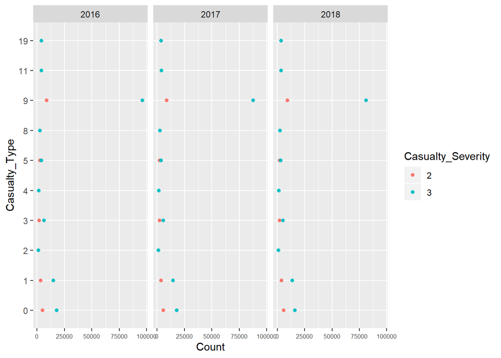

```r
casualty_type <- casualties[casualties$Casualty_Type != -1, ] %>%
            group_by(Casualty_Type, Casualty_Severity, Year) %>%
            summarise(Count = n())

#sort(casualty_type$Count)

top_casualty_type <- casualty_type[casualty_type$Count > 1000, ]



ggplot(data=top_casualty_type, aes(x=Casualty_Type, y=Count, color=Casualty_Severity)) +
  geom_point() +
  facet_wrap(~Year) +
  coord_flip() +
  theme(axis.text.x = element_text(size=6))
```

-We can see over the year most casualties are of type 9, 0 & 1 which represent Car occupant, Pedestrian & Cyclist respectively. -type 8 which represent taxi, have low casualties but again we are not aware of the actual number of taxi on roads.

```r
## Pedestrain Casualties Cases

table(casualties$Pedestrian_Location)
```

```
##
##     -1      0      1      2      3      4      5      6      7      8
##      9 443185  10842    339    161   5154  29736   7312    356   2648
##      9     10
##   7141   6091
```

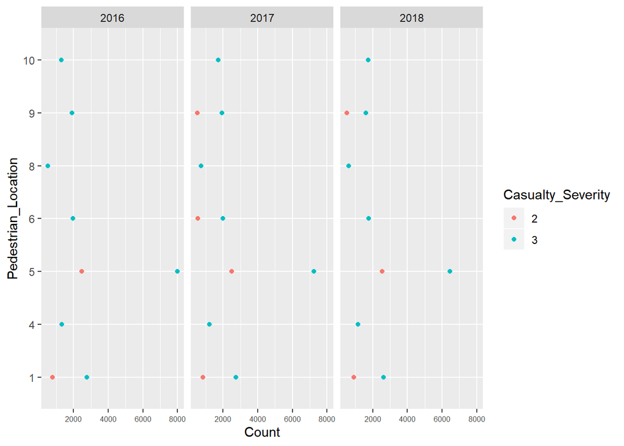

```r
t = (casualties$Casualty_Type  == 0 & casualties$Pedestrian_Location != -1)

pedestrian_casualties <- casualties[t, ] %>%
            group_by(Pedestrian_Location, Casualty_Severity, Year) %>%
            summarise(Count = n())

#pedestrian_casualties[pedestrian_casualties$Casualty_Severity == 1, ]

ggplot(data=pedestrian_casualties[pedestrian_casualties$Count > 500, ], aes(x=Pedestrian_Location, y=Count, color=Casualty_Severity)) +
  geom_point() +
  facet_wrap(~Year) +
  coord_flip() +
  theme(axis.text.x = element_text(size=6))
```

-The below graph show the location with with pedestrain casualty count more than 500. -Most of the pedestrian have slight severity. -While cases for location at 1, 5 which is “Crossing on pedestrian crossing facility” & “In carriageway, crossing elsewhere” have some serious severity cases. -It may suggest that people are being irresponsible and not using pedestrain crossing for case 5.

-Then there are some cases at location 6 which is “On footway or verge” suggest drivers are being irresponsible. -cases at location 9 which is In carriageway, not crossing. So it is similar to case 5.

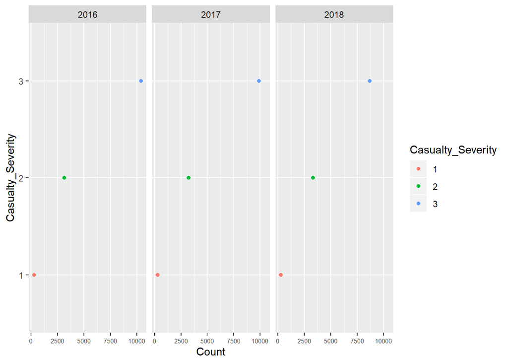

```r
## Pedestrain in Carriageway Casualties Cases
pedestrain_in_carriageway <- pedestrian_casualties[(pedestrian_casualties$Pedestrian_Location == 9 |
                       pedestrian_casualties$Pedestrian_Location == 5 |
                       pedestrian_casualties$Pedestrian_Location == 8), ]


pedestrain_in_carriageway <- pedestrain_in_carriageway %>%
            group_by(Casualty_Severity, Year) %>%
            summarise(Count = sum(Count))

ggplot(data=pedestrain_in_carriageway, aes(x=Casualty_Severity, y=Count, color=Casualty_Severity)) +
  geom_point() +
  facet_wrap(~Year) +
  coord_flip() +
  theme(axis.text.x = element_text(size=6))
```

-Fatal & serious Casualties count have not improved much perhaps serious cases have slightly increase over year. -Slight casualties case count have improved over year.

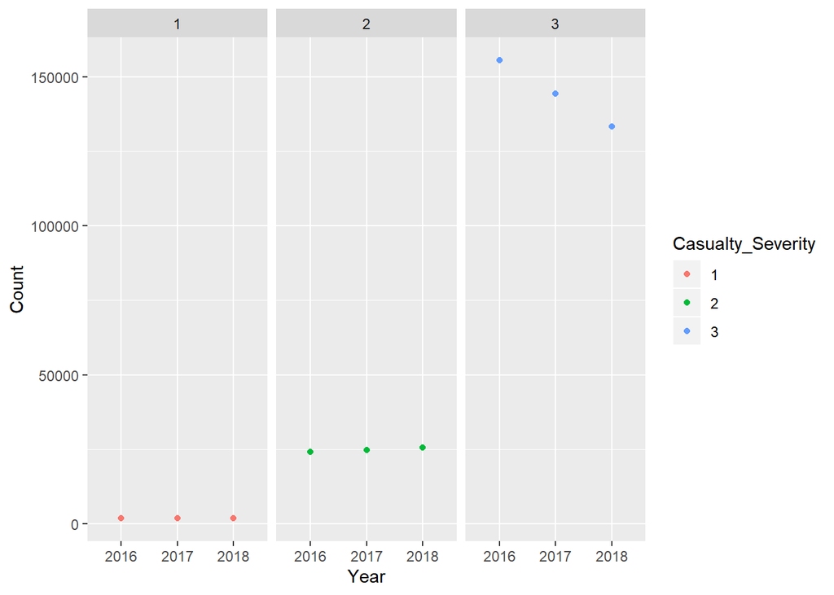

```r
#unique(casualties$Casualty_Severity)

severity <- casualties %>%
            group_by(Casualty_Severity, Year) %>%
            summarise(Count = n())

ggplot(data=severity, aes(x=Year, y=Count, color=Casualty_Severity)) +
  geom_point() +
  facet_wrap(~Casualty_Severity)
```

Severities type 1 & 2 are almost same over year 2016 to 2018 but there has been decrease in type 3 over the years. 1 - Fatal, 2 - Serious, 3 - Slight

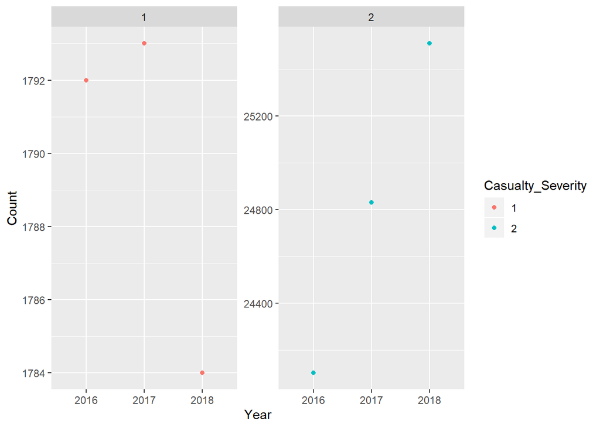

```r
## Considering fatal & serious cases
ggplot(data=severity[severity$Casualty_Severity != 3, ], aes(x=Year, y=Count, color=Casualty_Severity)) +
  geom_point() +
  facet_wrap(~Casualty_Severity, scales = "free")
```

While consdering just the carriage way for pedesterian we notice similar trend, fatal cases have not imporved much and there is increase in serious cases over the year.

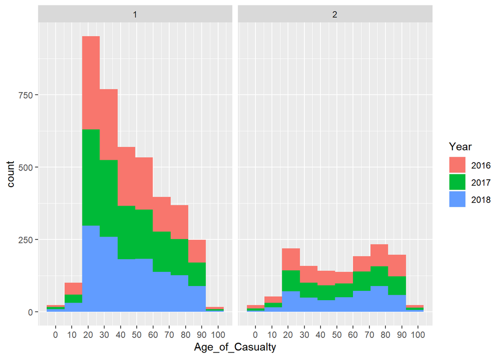

```r
## Fatal Cases
fatalities <- casualties[casualties$Casualty_Severity == 1, ]

ggplot(data=fatalities[fatalities$Age_of_Casualty != -1, ], aes(x=Age_of_Casualty)) +
  geom_histogram(bins=10, aes(fill=Year)) +
  scale_x_continuous(breaks = seq(0,100,10)) +
  facet_wrap(~Sex_of_Casualty)
```

-Fatal casualties are higest among yonger male which reduces with age. -For female fatalties is high for yonger female which slight decrease for age group till 60, and then its again high for age 60 to aroud 90. -There has been a similar trend over the year.

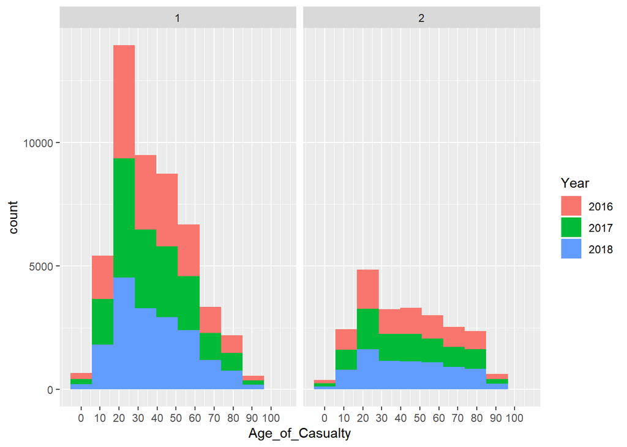

```r
## Serious Severity Cases
serious_severity <- casualties[casualties$Casualty_Severity == 2, ]

serious_severity <- serious_severity[serious_severity$Sex_of_Casualty != -1, ]

ggplot(data=serious_severity[serious_severity$Age_of_Casualty != -1, ], aes(x=Age_of_Casualty)) +
  geom_histogram(bins=10, aes(fill=Year)) +
  scale_x_continuous(breaks = seq(0,100,10)) +
  facet_wrap(~Sex_of_Casualty)
```

-Similar to fatal casualties, serious severity case are higest among yonger male which reduces with age. -For female serious severity is high for yonger female, but after age 30 it reduces with age. -There has been a similar trend over the year.

-Either there are more number of younger population on the road or there is more casualties among this age.